# Predicting Forest Cover Types from Cartographic Variables

### Distribution of Binary Variables

Now we'll analyse our binary variables and their distributions using countplot and see if there are any anomalies present.

```python
binary_data=forest.loc[:,'Wilderness_Area1':'Soil_Type40']
```

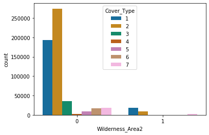

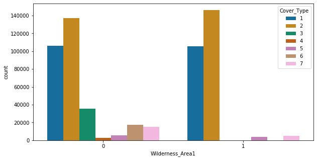

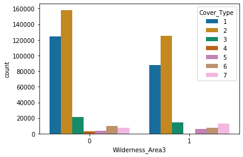

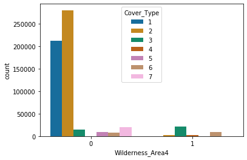

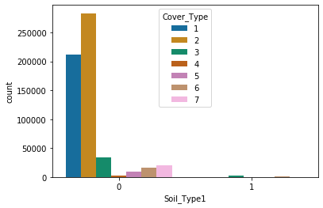

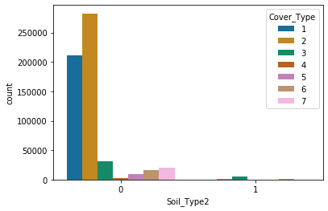

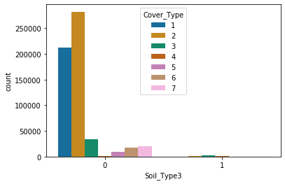

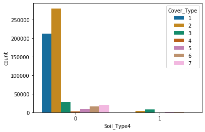

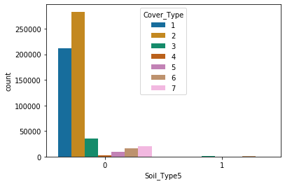

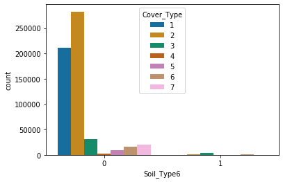

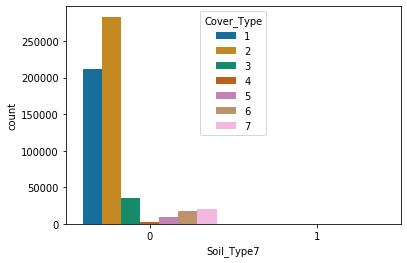

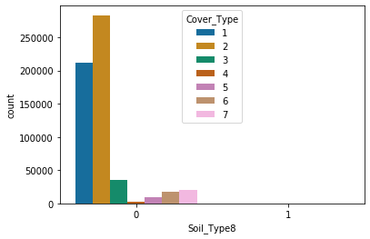

[32 more figures not shown]

```python
for i, col in enumerate(binary_data.columns):
    plt.figure()
    plt.figure(i,figsize=(10,5))
    sns.countplot(x=col, hue=forest['Cover_Type'] ,data=forest, palette="colorblind")
```

Few of the most interesting binary variables are:

- Wilderness_Area2: Most of the Cover_types 1 and 2 don't belong to Wilderness_Area2 but there are few present.
- Wilderness_Area4: Most of the Cover_types 1 and 2 don't belong to Wilderness_Area4 but there are a few other cover_types present.
- Soil_Type1, Soil_Type2, Soil_Type3, Soil_Type4, Soil_Type5, Soil_Type6: Most of the Cover_types 1 and 2 don't belong to them but few of cover_type3 is present.
- Soil_Type10: Most of the Cover_types 1 and 2 don't belong to Soil_Type10 but some portion of cover_type2 and cover_type3 are present.
- Soil_Type11, Soil_Type12, Soil_Type13, : Most of the Cover_types 1 and 2 don't belong to them but there is little of cover_type2 present.
- Soil_Type22, Soil_Type23, Soil_Type24, Soil_Type29, Soil_Type30, Soil_Type31, Soil_Type32, Soil_Type33: Most of the Cover_types 1 and 2 don't belong to them but there is some portion of cover_type2 and cover_type1 present.
- Soil_Type38, Soil_Type39, Soil_Type40: Most of the Cover_types 1 and 2 don't belong to them but there few of cover_type2 and cover_type1 are present.

### Cleaning Data

###### Checking binary variables that have less than 500 occurences:

```
Soil Type  Occurence_count
Soil_Type7 105
Soil_Type8 179
Soil_Type15 3
Soil_Type25 474
Soil_Type36 119
Soil_Type37 298
```

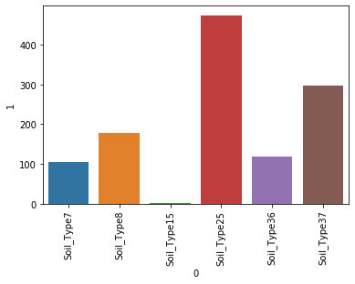

```python
counts_less = []
rem_cols = []

print('Soil Type',' Occurence_count')
for col in binary_data:
    count=binary_data[col].value_counts()[1] #considering all one's among 1 and 0's in each soil type
    if count < 500:
        print(col,count)
        counts_less.append([col,count])
        rem_cols.append(col)

df_occurence = pd.DataFrame.from_records(counts_less)

sns.barplot(x=df_occurence[0],y=df_occurence[1],data=df_occurence)
plt.xticks(rotation=90)

forest.drop(rem_cols,axis=1,inplace=True)
```

No duplicates or missing values so no row will be deleted.

### Standardize Continuous

```python
#point where categorical data begins
size=10
scaler = StandardScaler()

forest[forest.columns[0:size]] = scaler.fit_transform(forest[forest.columns[0:size]])
```

##### Box Plot After Standardizing:

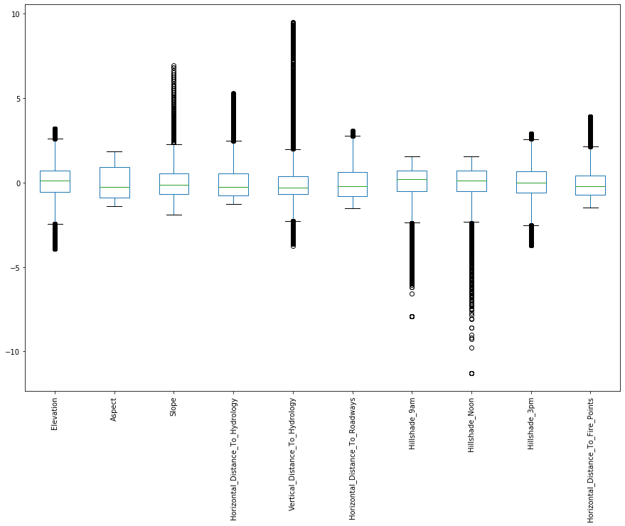

```python
forest[forest.columns[0:size]].plot(kind='box',figsize=(15,10))
plt.xticks(rotation=90)
plt.show()
```

### Spliting Data

As observed above, our data is imbalanced so it is necessary to resample it. This needs to be done in order to make our training data have balanced target classes.

```python
forest['ID'] =  forest.index

# Separate rows by target variable

df_cover_type_1 = forest[forest.Cover_Type == 1]
df_cover_type_2 = forest[forest.Cover_Type == 2]
df_cover_type_3 = forest[forest.Cover_Type == 3]
df_cover_type_4 = forest[forest.Cover_Type == 4]
df_cover_type_5 = forest[forest.Cover_Type == 5]
df_cover_type_6 = forest[forest.Cover_Type == 6]
df_cover_type_7 = forest[forest.Cover_Type == 7]

# resample 1500 rows from each class into our traning data

df_cover_type_1_resampled = resample(df_cover_type_1, replace=True, n_samples=1500, random_state=123)
df_cover_type_2_resampled = resample(df_cover_type_2, replace=True, n_samples=1500, random_state=123)
df_cover_type_3_resampled = resample(df_cover_type_3, replace=True, n_samples=1500, random_state=123)
df_cover_type_4_resampled = resample(df_cover_type_4, replace=True, n_samples=1500, random_state=123)
df_cover_type_5_resampled = resample(df_cover_type_5, replace=True, n_samples=1500, random_state=123)
df_cover_type_6_resampled = resample(df_cover_type_6, replace=True, n_samples=1500, random_state=123)
df_cover_type_7_resampled = resample(df_cover_type_7, replace=True, n_samples=1500, random_state=123)



# Combine Selected rows into a balanced df which will be training data
df_balanced = pd.concat([df_cover_type_1_resampled,
                         df_cover_type_2_resampled,
                        df_cover_type_3_resampled,
                        df_cover_type_4_resampled,
                        df_cover_type_5_resampled,
                        df_cover_type_6_resampled,
                        df_cover_type_7_resampled])
```

```python
test_df = forest.loc[forest['ID'].isin(list(df_balanced['ID'])) == False]
train_df = df_balanced.drop(['ID'],axis = 1)
test_df = test_df.drop(['ID'],axis = 1)
```

```python
y_train_df = train_df['Cover_Type']
X_train_df = train_df.drop(['Cover_Type'],axis =1)

y_test_df = test_df['Cover_Type']
X_test_df = test_df.drop(['Cover_Type'],axis =1)
```

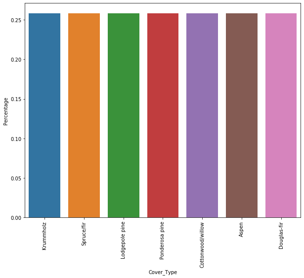

```python
class_distribution = (train_df.groupby('Cover_Type').size() / 581011) * 100
percentages = []
for i in enumerate(class_distribution):
    percentages.append( [i[1],cover_types[i[0] - 1]  ] )
class_labels = pd.DataFrame(percentages,columns=['Percentage','Cover_Type'])
plt.figure(figsize=(10,8))
sns.barplot(x='Cover_Type',y='Percentage',data=class_labels)
plt.xticks(rotation=90)
```

Our Class Distribution is balanced in training Data.

### Feature Selection

Selecting 75% of the Top Ranking Features from the forest dataset using RFE.

```python
feature_cols= forest.columns
c = len(feature_cols)
estimator= LinearRegression()
sel= RFE (estimator,20)
sel= sel.fit(X_train_df,y_train_df)
joined = []
for i, pred in enumerate(list(sel.ranking_)):
            joined.append([i,feature_cols[i],pred])
joined_sorted = sorted(joined, key=lambda x: x[2])

# top 75% of selected features
sel_len = int((0.75*(c-1)))

len(joined_sorted[0:sel_len])

selected_features = []


for i,name,rank in joined_sorted[0:sel_len]:
    selected_features.append(name)
selected_features
```

```
['Wilderness_Area1',
 'Wilderness_Area2',
 'Wilderness_Area3',
 'Wilderness_Area4',
 'Soil_Type4',
 'Soil_Type9',
 'Soil_Type12',
 'Soil_Type19',
 'Soil_Type20',
 'Soil_Type21',
 'Soil_Type22',
 'Soil_Type23',
 'Soil_Type24',
 'Soil_Type26',
 'Soil_Type27',
 'Soil_Type28',
 'Soil_Type29',
 'Soil_Type31',
 'Soil_Type32',
 'Soil_Type33',
 'Soil_Type11',
 'Soil_Type13',
 'Soil_Type34',
 'Soil_Type2',
 'Soil_Type3',
 'Soil_Type17',
 'Soil_Type16',
 'Soil_Type1',
 'Soil_Type6',
 'Soil_Type14',
 'Soil_Type10',
 'Soil_Type5',
 'Soil_Type18',
 'Soil_Type30',
 'Horizontal_Distance_To_Roadways',
 'Soil_Type39']
```

### Creating DF of selected features only

```python
X_train_selected_df = X_train_df[selected_features]
X_test_selected_df  = X_test_df[selected_features]
```

### Baseline Model - Logistic Regression

A baseline model using Logistic Regression Model is created in order to use it as a reference point to track the progress.

```python
all_results = []
```

```python
logreg = linear_model.LogisticRegression()
logreg.fit(X_train_df, y_train_df)


accuracy_logreg_train = logreg.score(X_train_df,y_train_df)
accuracy_logreg_test = logreg.score(X_test_df,y_test_df)
print('train',accuracy_logreg_train)
print('test',accuracy_logreg_test)
features_used = len(X_train_df.columns)

all_results.append(['Logistic Regression','Train',accuracy_logreg_train,features_used])
all_results.append(['Logistic Regression','Test',accuracy_logreg_test,features_used])
```

```
train 0.6805714285714286
test 0.5534451995188224
```

This will be our baseline Model, it gives 55.3% accuracy on Test Data and 68.05% accuracy on Traning Data.

### Logistic Regression with Selected Features

```python
logreg = linear_model.LogisticRegression()
logreg.fit(X_train_selected_df, y_train_df)



accuracy_logreg_train = logreg.score(X_train_selected_df,y_train_df)
accuracy_logreg_test = logreg.score(X_test_selected_df,y_test_df)
print('train',accuracy_logreg_train)
print('test',accuracy_logreg_test)
features_used = len(X_train_selected_df.columns)

all_results.append(['Logistic Regression - Selected Features','Train',accuracy_logreg_train,features_used])
all_results.append(['Logistic Regression - Selected Features','Test',accuracy_logreg_test,features_used])
```

```
train 0.6135238095238095
test 0.48955610148152945
```

Logistic Regression model using selected features the accuracy has decreased, it is now 61.3% accuracte on training data and 48.9% accurate on Test Data.

### Build a Naive Bayes Model

Naive Bayes Model is built on the original test and train data as well as the selected features to check how well this model works againist the others.

### GaussianNB

```python
gbnb = GaussianNB()
gbnb.fit(X_train_df, y_train_df)
y_pred = gbnb.predict(X_test_df)
```

```python
accuracy_gbnb_train = gbnb.score(X_train_df,y_train_df)
accuracy_gbnb_test = gbnb.score(X_test_df,y_test_df)
print('train',accuracy_gbnb_train)
print('test',accuracy_gbnb_test)
features_used = len(X_train_df.columns)
```

```
train 0.44257142857142856
test 0.1524236603461046
```

```python
all_results.append(['Naive Bayes Gaussian NB','Train',accuracy_gbnb_train,features_used])
all_results.append(['Naive Bayes Gaussian NB','Test',accuracy_gbnb_test,features_used])
```

### GaussianNB with Selected Features

```python
gbnb_extract = GaussianNB()
gbnb_extract.fit(X_train_selected_df, y_train_df)

accuracy_gbnb_extract_train = gbnb_extract.score(X_train_selected_df,y_train_df)
accuracy_gbnb_extract_test = gbnb_extract.score(X_test_selected_df,y_test_df)
print('train',accuracy_gbnb_extract_train)
print('test',accuracy_gbnb_extract_test)
features_used = len(X_train_selected_df.columns)
```

```
train 0.4103809523809524
test 0.12452832170954597
```

Using only selected features with naive Bayes there is a small drop in accuracy its is now 41.03% on training and 12.45% on test data.

```python
all_results.append(['Naive Bayes Gaussian NB -Selected Features','Train',accuracy_gbnb_extract_train,features_used])
all_results.append(['Naive Bayes Gaussian NB -Selected Features','Test',accuracy_gbnb_extract_test,features_used])
```

### KNN

k-nearest neighbors algorithm on the test and train data.

```python
knn_range = list(range(1, 6))
result = []
for i in knn_range:
    knn = KNeighborsClassifier(n_neighbors = i)
    knn.fit(X_train_df, y_train_df)
    accuracy_knn_train = knn.score(X_train_df,y_train_df)
    accuracy_knn_test = knn.score(X_test_df,y_test_df)
    result.append([i,accuracy_knn_train,accuracy_knn_test])
result
```

[output not shown]

The optimal K value for KNN is 2 for Test Data and 1 for traning Data. We got Accuracy of 100% for Train Data and 66.4% For test Data with value of K = 1, and 92.5% and 66.6% with value of k = 2 respectivly. we'll choose K = 2.

```python
features_used = len(X_train_df.columns)
all_results.append(['KNN - k=2','Train',result[1][1],features_used])
all_results.append(['KNN - k=2','Test',result[1][2],features_used])
```

### KNN with Selected Features

```python
knn_range = list(range(1, 6))
result = []
for i in knn_range:
    knn = KNeighborsClassifier(n_neighbors = i)
    knn.fit(X_train_selected_df, y_train_df)
    accuracy_knn_extract_train = knn.score(X_train_selected_df,y_train_df)
    accuracy_knn_extract_test = knn.score(X_test_selected_df,y_test_df)
    result.append([i,accuracy_knn_extract_train,accuracy_knn_extract_test])
result
```

[output not shown]

```python
features_used = len(X_train_selected_df.columns)
all_results.append(['KNN - k=2 - Selected Features','Train',result[1][1],features_used])
all_results.append(['KNN - k=2 - Selected Features','Test',result[1][2],features_used])
```

### Selecting best Hidden layer size for NN

```python
hidden_unit =  [(110,110),(120,120),(130,130),(140,140),(180,180)]
result = []

for i in hidden_unit:
    mlp = MLPClassifier(solver='adam', random_state=0, hidden_layer_sizes=i,max_iter=400 )
    mlp.fit(X_train_df,y_train_df)
    result.append([ mlp.score(X_train_df,y_train_df),i,'train'])
    result.append([mlp.score(X_test_df,y_test_df),i,'test'])

result_df = pd.DataFrame.from_records(result)
```

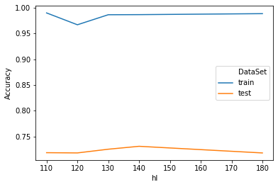

```python
result_df.columns = ['Accuracy','HiddenLayer','DataSet']
result_df['hl'] = result_df.apply(lambda row: row.HiddenLayer[0], axis = 1)
ax = sns.lineplot(x='hl', y='Accuracy', hue='DataSet',data=result_df)
```

From the line plot above it can be observed that the hidden layer value of 110 gives the best accuracy ,almost 100% for our training data. Where as the hidden layer value of 140 gives the best accuracy, almost 75% for our test data.

### Selecting best Num of Ietrations

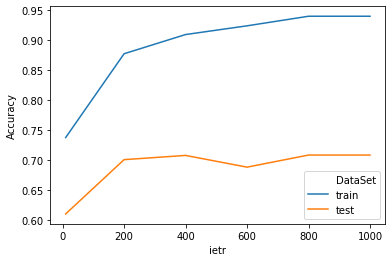

```python
ietr =   [10,200,400,600,800,1000]
result = []

for i in ietr:
    mlp = MLPClassifier(solver='adam', random_state=0,max_iter=i,hidden_layer_sizes=120)
    mlp.fit(X_train_df,y_train_df)
    result.append([ mlp.score(X_train_df,y_train_df),i,'train'])
    result.append([mlp.score(X_test_df,y_test_df),i,'test'])

result_df = pd.DataFrame.from_records(result)
result_df.columns = ['Accuracy','ietr','DataSet']
ax = sns.lineplot(x='ietr', y='Accuracy', hue='DataSet',data=result_df)
```

It can be observed from the line plot that the iteration value of 800 gives the best accuracy, almost 95% for our training data and the iteration value of 200 or 400 gives the best accuracy, almost 70% for our test data.

### Selecting Best Solver

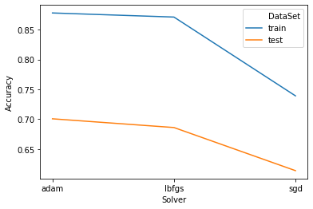

```python
solvers = ['lbfgs','sgd', 'adam']
result = []

for i in solvers:
    mlp = MLPClassifier(solver=i, random_state=0,max_iter=200,hidden_layer_sizes=120)
    mlp.fit(X_train_df,y_train_df)
    result.append([ mlp.score(X_train_df,y_train_df),i,'train'])
    result.append([mlp.score(X_test_df,y_test_df),i,'test'])

result_df = pd.DataFrame.from_records(result)
result_df.columns = ['Accuracy','Solver','DataSet']
ax = sns.lineplot(x='Solver', y='Accuracy', hue='DataSet',data=result_df)
```

We checked which classifier would provide the most accurate result on our data set and 'adam' tends to provide the highest accuracy for the train and test data compared to the other classifiers.

### Selecting Best 'alpha' for NN

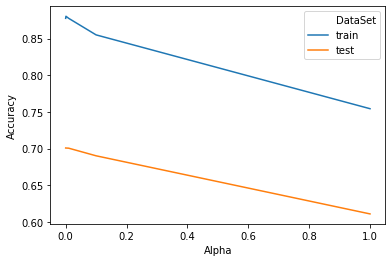

```python
alpha = [0.0001,0.001,0.01, 0.1,1]

result = []

for i in alpha:
    mlp = MLPClassifier(solver='adam', random_state=0,max_iter=200,hidden_layer_sizes=120, alpha=i)
    mlp.fit(X_train_df,y_train_df)
    result.append([ mlp.score(X_train_df,y_train_df),i,'train'])
    result.append([mlp.score(X_test_df,y_test_df),i,'test'])

result_df = pd.DataFrame.from_records(result)
result_df.columns = ['Accuracy','Alpha','DataSet']
ax = sns.lineplot(x='Alpha', y='Accuracy', hue='DataSet',data=result_df)
```

From the line plot above it can be observed that the alpha value of 0.0 gives the best accuracy, greater than 85% for our training data and 70% for our test data.

### Using Best Values Infered from Above Tests for Final NN

```python
mlp = MLPClassifier(solver='adam', random_state=0,max_iter=1000,hidden_layer_sizes=(140,140), alpha=0.0001)
mlp.fit(X_train_df,y_train_df)

train_mlp = mlp.score(X_train_df,y_train_df)
test_mlp = mlp.score(X_test_df,y_test_df)
features_used = len(X_train_df.columns)
print(['Neural Network','Train',train_mlp,features_used])
print(['Neural Network','Test',test_mlp,features_used])
```

```
['Neural Network', 'Train', 0.9869523809523809, 48]
['Neural Network', 'Test', 0.730705184214996, 48]
```

Neural Network with the chosen values from above experiments gives the best accuracy for 48 features, 98.69% for train data and 73.07% for test data.

```python
all_results.append(['Neural Network','Train',train_mlp,features_used])
all_results.append(['Neural Network','Test',test_mlp,features_used])
```

### Neural Network with Selected Features

```python
mlp = MLPClassifier(solver='adam', random_state=0,max_iter=1000,hidden_layer_sizes=(140,140), alpha=0.0001)
mlp.fit(X_train_selected_df,y_train_df)

train_mlp = mlp.score(X_train_selected_df,y_train_df)
test_mlp = mlp.score(X_test_selected_df,y_test_df)
features_used = len(X_train_selected_df.columns)
print(['Neural Network - Selected Features','Train',train_mlp,features_used])
print(['Neural Network - Selected Features','Test',test_mlp,features_used])
```

```
['Neural Network - Selected Features', 'Train', 0.6801904761904762, 36]
['Neural Network - Selected Features', 'Test', 0.5119094938005495, 36]
```

```python
all_results.append(['Neural Network - Selected Features','Train',train_mlp,features_used])
all_results.append(['Neural Network - Selected Features','Test',test_mlp,features_used])
```

### Decision Tree Classifier

selecting best value for max_depth

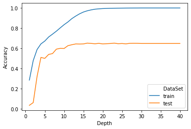

```python
max_depths = np.linspace(1, 40, 40, endpoint=True)
min_samples_splits = np.linspace(0.1, 1.0, 10, endpoint=True)
min_samples_leafs = np.linspace(0.1, 0.5, 5, endpoint=True)
max_features = list(range(1,X_train_df.shape[1]))


result = []
for i in max_depths:
    clf_pre_prun = DecisionTreeClassifier(random_state=0, max_depth=i)
    clf_pre_prun.fit(X_train_df,y_train_df)
    train_acc = clf_pre_prun.score(X_train_df,y_train_df)
    test_acc = clf_pre_prun.score(X_test_df,y_test_df)
    result.append([ train_acc,i,'train'])
    result.append([test_acc,i,'test'])

result_df = pd.DataFrame.from_records(result)
result_df.columns = ['Accuracy','Depth','DataSet']
ax = sns.lineplot(x='Depth', y='Accuracy', hue='DataSet',data=result_df)
plt.show()

result_df = result_df.loc[result_df['DataSet'] == 'test']
best_depth = result_df.loc[(result_df['DataSet'] == 'test') & (result_df['Accuracy'] == result_df['Accuracy'].max())].Depth.values[0]
```

```python
clf_pre_prun = DecisionTreeClassifier(random_state=0, max_depth=best_depth )
clf_pre_prun.fit(X_train_df,y_train_df)
train_acc = clf_pre_prun.score(X_train_df,y_train_df)
test_acc = clf_pre_prun.score(X_test_df,y_test_df)
print('train',train_acc)
print('test',test_acc)
features_used = len(X_train_df.columns)
all_results.append(['Decision Tree Classifier','Train',train_acc,features_used])
all_results.append(['Decision Tree Classifier','Test',test_acc,features_used])
```

```
train 0.9722857142857143
test 0.6521373702282791
```

We get 65.21% accuracy with Decision tree classfier, for our test data and 97.22% accuracy for our training data.

### Decision Tree Classifier With Selected features

```python
clf_pre_prun = DecisionTreeClassifier(random_state=0, max_depth=best_depth )
clf_pre_prun.fit(X_train_selected_df,y_train_df)
train_acc = clf_pre_prun.score(X_train_selected_df,y_train_df)
test_acc = clf_pre_prun.score(X_test_selected_df,y_test_df)
print('train',train_acc)
print('test',test_acc)
features_used = len(X_train_selected_df.columns)
all_results.append(['Decision Tree Classifier - Selected','Train',train_acc,features_used])
all_results.append(['Decision Tree Classifier - Selected','Test',test_acc,features_used])
```

```
train 0.7450476190476191
test 0.5387542265001339
```

With Selected Features our Test data gave us 53.87% accuracy and training data has 74.50% accuracy.

### Compare All Models - (Plots)

```python
result_df = pd.DataFrame.from_records(all_results)
result_df.columns =['Model','DataSet','Accuracy','Num Of Features']
result_df
```

|  | Model | DataSet | Accuracy | Num Of Features |
| --- | --- | --- | --- | --- |
| 0 | Logistic Regression | Train | 0.680571 | 48 |
| 1 | Logistic Regression | Test | 0.553445 | 48 |
| 2 | Logistic Regression - Selected Features | Train | 0.613524 | 36 |
| 3 | Logistic Regression - Selected Features | Test | 0.489556 | 36 |
| 4 | Naive Bayes Gaussian NB | Train | 0.442571 | 48 |
| 5 | Naive Bayes Gaussian NB | Test | 0.152424 | 48 |
| 6 | Naive Bayes Gaussian NB -Selected Features | Train | 0.410381 | 36 |
| 7 | Naive Bayes Gaussian NB -Selected Features | Test | 0.124528 | 36 |
| 8 | KNN - k=2 | Train | 0.925048 | 48 |
| 9 | KNN - k=2 | Test | 0.666846 | 48 |
| 10 | KNN - k=2 - Selected Features | Train | 0.917524 | 36 |
| 11 | KNN - k=2 - Selected Features | Test | 0.493100 | 36 |
| 12 | Neural Network | Train | 0.986952 | 48 |
| 13 | Neural Network | Test | 0.730705 | 48 |
| 14 | Neural Network - Selected Features | Train | 0.680190 | 36 |
| 15 | Neural Network - Selected Features | Test | 0.511909 | 36 |
| 16 | Decision Tree Classifier | Train | 0.972286 | 48 |
| 17 | Decision Tree Classifier | Test | 0.652137 | 48 |
| 18 | Decision Tree Classifier - Selected | Train | 0.745048 | 36 |
| 19 | Decision Tree Classifier - Selected | Test | 0.538754 | 36 |

### Top Perfroming Models on Test data

```python
result_dff = result_df.loc[result_df['DataSet'] == 'Test']
result_dff.sort_values('Accuracy', ascending = False)
```

|  | Model | DataSet | Accuracy | Num Of Features |
| --- | --- | --- | --- | --- |
| 13 | Neural Network | Test | 0.730705 | 48 |
| 9 | KNN - k=2 | Test | 0.666846 | 48 |
| 17 | Decision Tree Classifier | Test | 0.652137 | 48 |
| 1 | Logistic Regression | Test | 0.553445 | 48 |
| 19 | Decision Tree Classifier - Selected | Test | 0.538754 | 36 |
| 15 | Neural Network - Selected Features | Test | 0.511909 | 36 |
| 11 | KNN - k=2 - Selected Features | Test | 0.493100 | 36 |
| 3 | Logistic Regression - Selected Features | Test | 0.489556 | 36 |
| 5 | Naive Bayes Gaussian NB | Test | 0.152424 | 48 |
| 7 | Naive Bayes Gaussian NB -Selected Features | Test | 0.124528 | 36 |

```
([0, 1, 2, 3, 4, 5, 6, 7, 8, 9], <a list of 10 Text xticklabel objects>)
```

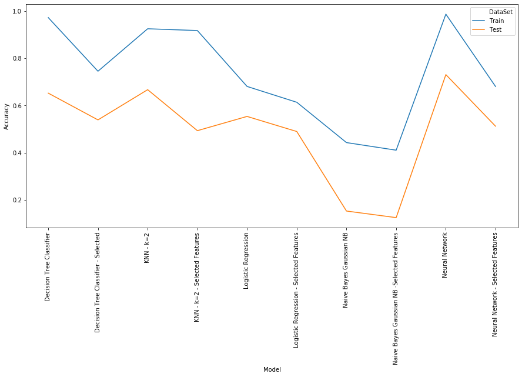

```python
plt.figure(figsize=(15,7))
g = sns.lineplot(x="Model", y="Accuracy",hue="DataSet", data=result_df)
plt.xticks(rotation=90)
```

### Conclusion

All the models in the above graph present lower accuracy for selected features compared to using all features. Some other feature selection tenchinque could be applied to get a better outcome. To Further increase accuracy of the model, different Neural Network Structure can be used.